# Correlations among baseline features and lapse

Author

Kendra Wyant

Published

August 27, 2025

## Set Up

```r
library(tidyverse)
library(tidymodels)
theme_set(theme_classic())

source("https://github.com/jjcurtin/lab_support/blob/main/format_path.R?raw=true")

path_shared <- "/Volumes/studydata/risk/data_processed/shared"
```

## Read in data

```r
study_dates <- read_csv(here::here(path_shared, "study_dates_messages.csv"),
                  show_col_types = FALSE)

baseline <- read_csv(here::here(path_shared, "features_baseline.csv"),
                  show_col_types = FALSE) |>
  filter(subid %in% study_dates$subid) |>
  # select scaled and other scores not in raw data
  select(subid, days_abstinent, dsm5_total:efficacy_craving, stress_total:social_support_so)

intake <- read_csv(here::here(path_shared, "intake.csv"),
                  show_col_types = FALSE) |>
  filter(subid %in% study_dates$subid) |>
  select(-c(2:6))

screen <- read_csv(here::here(path_shared, "screen.csv"),
                  show_col_types = FALSE) |>
  filter(subid %in% study_dates$subid) |>
  select(-c(2:6), -starts_with("mps_"), -starts_with("auh_8"))

feats <- baseline |>
  left_join(intake, by = "subid") |>
  left_join(screen, by = "subid")

labels <- read_csv(here::here(path_shared, "labels_messages_day_24h.csv"),
                  show_col_types = FALSE) |>
  select(-c(day_start, day_end)) |>
  mutate(lapse = factor(lapse, levels = c("lapse", "no lapse")))

strat <- read_csv(here::here(path_shared, "strat_lh.csv"),
                  show_col_types = FALSE)
```

Remove feats with more than 10% missing data

```r
feats_missing <- naniar::miss_var_summary(feats) |>
  filter(pct_miss > 10) |>
  pull(variable)

feats <- feats |>
  select(-c(contains(feats_missing)))
```

Add outcome and strat var

```r
data <- labels |>
  left_join(feats, by = "subid") |>
  left_join(strat, by = "subid")
```

Convert string variables to factor

```r
data <- data |>
  mutate(across(where(is.character), ~factor(.x))) |>
  rename(y = lapse)

glimpse(data)
```

```
Rows: 11,967
Columns: 401
$ subid                  <dbl> 2, 2, 2, 2, 2, 2, 2, 2, 2, 2, 2, 2, 2, 2, 2, 2,…
$ dttm_label             <dttm> 2017-03-25 09:00:00, 2017-03-26 09:00:00, 2017…
$ y                      <fct> no lapse, no lapse, no lapse, no lapse, no laps…
$ days_abstinent         <dbl> 54, 54, 54, 54, 54, 54, 54, 54, 54, 54, 54, 54,…
$ dsm5_total             <dbl> 9, 9, 9, 9, 9, 9, 9, 9, 9, 9, 9, 9, 9, 9, 9, 9,…
$ craving_total          <dbl> 11, 11, 11, 11, 11, 11, 11, 11, 11, 11, 11, 11,…
$ efficacy_neg_affect    <dbl> 8, 8, 8, 8, 8, 8, 8, 8, 8, 8, 8, 8, 8, 8, 8, 8,…
$ efficacy_social        <dbl> 11, 11, 11, 11, 11, 11, 11, 11, 11, 11, 11, 11,…
$ efficacy_physical      <dbl> 1, 1, 1, 1, 1, 1, 1, 1, 1, 1, 1, 1, 1, 1, 1, 1,…
$ efficacy_craving       <dbl> 0, 0, 0, 0, 0, 0, 0, 0, 0, 0, 0, 0, 0, 0, 0, 0,…
$ stress_total           <dbl> 13, 13, 13, 13, 13, 13, 13, 13, 13, 13, 13, 13,…
$ social_support_family  <dbl> 22, 22, 22, 22, 22, 22, 22, 22, 22, 22, 22, 22,…
$ social_support_friends <dbl> 15, 15, 15, 15, 15, 15, 15, 15, 15, 15, 15, 15,…
```

[output cut: 388 more lines]

## Make features

Recipe

```r
rec <- recipe(y ~ ., data = data) |>
  step_rm(subid, dttm_label, strat) |>
  step_zv(all_predictors()) |>
  step_impute_median(all_numeric_predictors()) |>
  step_impute_mode(all_nominal_predictors()) |>
  step_dummy(all_nominal_predictors()) |>
  step_nzv(all_predictors()) |>
  step_normalize(all_predictors())
```

```r
rec_prepped <- rec |>
    prep(training = data)

feat_all <- rec_prepped |>
    bake(new_data = data)

glimpse(feat_all)
```

```
Rows: 11,967
Columns: 1,121
$ days_abstinent                                                                    <dbl> …
$ dsm5_total                                                                        <dbl> …
$ craving_total                                                                     <dbl> …
$ efficacy_neg_affect                                                               <dbl> …
$ efficacy_social                                                                   <dbl> …
$ efficacy_physical                                                                 <dbl> …
$ efficacy_craving                                                                  <dbl> …
$ stress_total                                                                      <dbl> …
$ social_support_family                                                             <dbl> …
$ social_support_friends                                                            <dbl> …
$ social_support_so                                                                 <dbl> …
$ mam_10                                                                            <dbl> …
$ mam_13                                                                            <dbl> …
```

[output cut: 1108 more lines]

## Get correlations

```r
cor_feat <- feat_all |>
  mutate(y = if_else(y == "no lapse", 0, 1))  |>
  cor() |>
  as_tibble(rownames = NA) |>
  rownames_to_column() |>
  filter(rowname != "y") |>
  select(feature = rowname, y) |>
  mutate(y = round(y, 3))

cor_feat |>
  arrange(desc(abs(y))) |>
  print(n = Inf)
```

```
# A tibble: 1,120 × 2
     feature                                                                   y
     <chr>                                                                 <dbl>
   1 mam_22_Yes                                                           -0.138
   2 mspss_1_Mildly.Disagree                                               0.134
   3 mam_23_Moderately                                                     0.133
   4 yap_1_X2.times.in.the.past.year                                       0.131
   5 qol_7_Very.disssatisfied                                              0.13
   6 scl90_25_Extremely                                                    0.125
   7 mam_22_Uncertain                                                      0.123
   8 dass21_15_Sometimes                                                  -0.118
   9 yap_13_No..never                                                      0.118
  10 mam_21_Extremely                                                     -0.115
  11 dass21_10_Often                                                       0.112
  12 mam_23_Extremely                                                     -0.11
```

[output cut: 1108 more lines]

Six of the 8 lasso selected variables are in the top 10:

- yap_1 - Have you driven a car when you knew you had too much to drink to drive safely? (responses include lifetime endorsement and past year frequency)
- mam_23 - In the next 30 days, how confident are you in your ability to be completely abstinent from alcohol?
- dass21_15 - In the past month, I felt I was close to panic.
- mspss_1 - There is a special person who is around when I am in need.
- mam_22 - Is your goal still to remain abstinent in the future?
- yap_13 - Have you ever neglected your obligations, your family, your work, or school work for two or more days in a row because of your drinking?

Other 2 lasso selected are in top 28:

- qol_13 - How satisfied are you with the conditions of your neighborhood?
- fad_38 - We [my family] resolve most emotional upsets that come up.

```r
cor_feat |>
  arrange(desc(abs(y))) |>
  filter(round(y, 2) >= .1) |>
  print(n = Inf)
```

```
# A tibble: 16 × 2
   feature                                                      y
   <chr>                                                    <dbl>
 1 mspss_1_Mildly.Disagree                                  0.134
 2 mam_23_Moderately                                        0.133
 3 yap_1_X2.times.in.the.past.year                          0.131
 4 qol_7_Very.disssatisfied                                 0.13
 5 scl90_25_Extremely                                       0.125
 6 mam_22_Uncertain                                         0.123
 7 yap_13_No..never                                         0.118
 8 dass21_10_Often                                          0.112
 9 dass21_16_Often                                          0.11
10 fad_13_Strongly.Agree                                    0.109
11 asi3_11_Somewhat.true.of.me                              0.108
12 aase_11_Very                                             0.105
13 pacs_1_Often...11.to.20.times.during.this.period.of.time 0.102
14 mam_23_Slightly                                          0.097
15 pss_9_Sometimes                                          0.096
16 aase_1_Moderately                                        0.095
```

Histogram of correlations

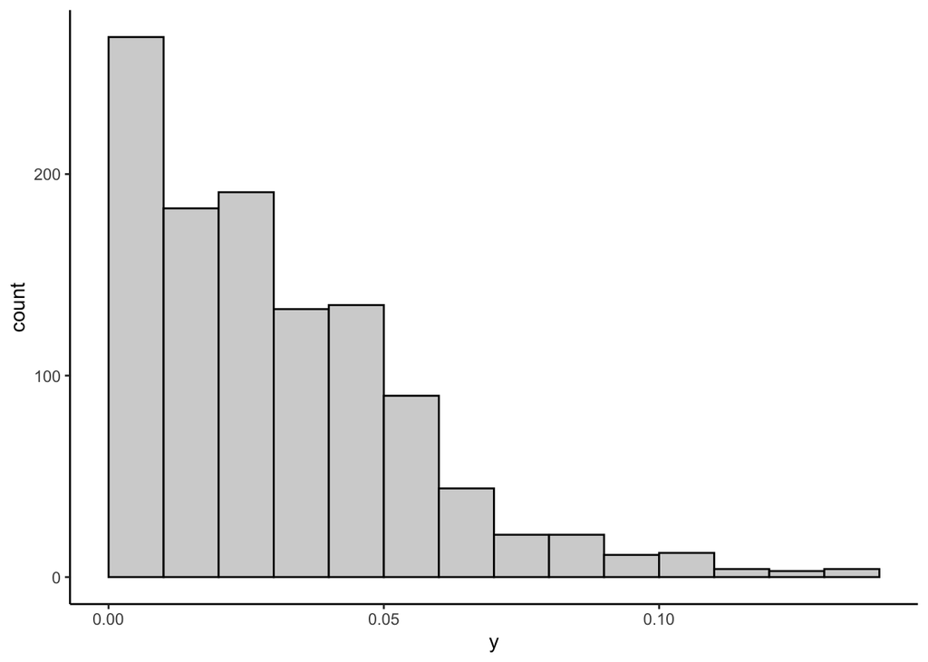

```r
cor_feat |>
  mutate(y = abs(y)) |>
  ggplot(aes(x = y)) +
  geom_histogram(binwidth = .01, boundary = 0, fill = "light grey", color = "black")
```